# Untitled

Annisa Marwah

2026-08-26

# LIBRARY

```r
library(forecast)
library(graphics)
library(TTR)
library(TSA)
library(readxl)
library(ggplot2)
```

# IMPORT DATA

```r
# Impor dataset dari file Excel
data_penumpang <- read_excel("Data Pilihan MPDW.xlsx", sheet = "Sheet1")

# Menampilkan 6 baris pertama data
head(data_penumpang)
```

```
## # A tibble: 6 × 2
##   Periode Jumlah_Penumpang
##     <dbl>            <dbl>
## 1       1            48208
## 2       2            55488
## 3       3            46777
## 4       4            57120
## 5       5            59794
## 6       6            59681
```

# EKPLORASI DATA

```r
# Struktur dan dimensi data
str(data_penumpang)
```

```
## tibble [100 × 2] (S3: tbl_df/tbl/data.frame)
##  $ Periode         : num [1:100] 1 2 3 4 5 6 7 8 9 10 ...
##  $ Jumlah_Penumpang: num [1:100] 48208 55488 46777 57120 59794 ...
```

```r
dim(data_penumpang)
```

```
## [1] 100   2
```

```r
# Mengubah variabel Jumlah_Penumpang menjadi objek deret waktu (time series)
penumpang.ts <- ts(data_penumpang$Jumlah_Penumpang)

# Ringkasan statistik deskriptif
summary(penumpang.ts)
```

```
##    Min. 1st Qu.  Median    Mean 3rd Qu.    Max.
##   41658   55604   60047   58687   62475   68622
```

## Plot Deret Waktu Keseluruhan

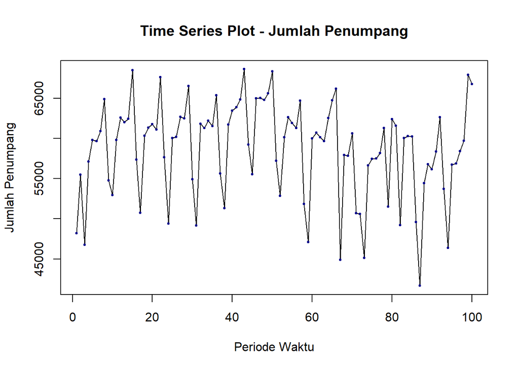

```r
ts.plot(penumpang.ts, xlab = "Periode Waktu", ylab = "Jumlah Penumpang",
        main = "Time Series Plot - Jumlah Penumpang")
points(penumpang.ts, pch = 20, col = "darkblue", cex = 0.6)
```

Berdasarkan plot deret waktu di atas, data Jumlah_Penumpang berfluktuasi pada rentang sekitar 41.658 hingga 68.622 dengan rata-rata 58.687 penumpang per periode. Terlihat adanya pola osilasi periodik yang berulang dan dinamis di sekitar nilai tengahnya tanpa adanya lonjakan tren linear jangka panjang yang ekstrem.

# SMA & DMA

## Pembagian Data Latih dan Data Uji

Pembagian data dilakukan dengan proporsi 80% data latih (training) dan 20% data uji (testing). Dengan total $N = 100$ observasi, data latih terdiri atas 80 observasi pertama dan data uji terdiri atas 20 observasi terakhir.

### Menghitung jumlah observasi

```r
n <- nrow(data_penumpang)
n_train <- floor(0.8 * n)
n_test  <- n - n_train

# Pembagian data frame
training_ma <- data_penumpang[1:n_train, ]
testing_ma  <- data_penumpang[(n_train + 1):n, ]

# Konversi ke objek time series
train_ma.ts <- ts(training_ma$Jumlah_Penumpang)
test_ma.ts  <- ts(testing_ma$Jumlah_Penumpang)

cat("Jumlah observasi total :", n, "\n")
```

```
## Jumlah observasi total : 100
```

```r
cat("Jumlah data latih      :", n_train, "\n")
```

```
## Jumlah data latih      : 80
```

```r
cat("Jumlah data uji        :", n_test, "\n")
```

```
## Jumlah data uji        : 20
```

### Visualisasi pembagian data latih dan uji

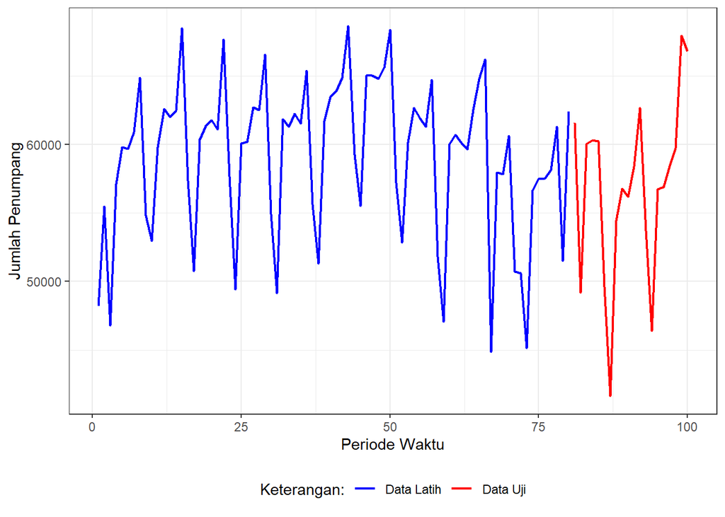

```r
ggplot() +
  geom_line(data = training_ma, aes(x = Periode, y = Jumlah_Penumpang, col = "Data Latih"), linewidth = 0.8) +
  geom_line(data = testing_ma, aes(x = Periode, y = Jumlah_Penumpang, col = "Data Uji"), linewidth = 0.8) +
  labs(x = "Periode Waktu", y = "Jumlah Penumpang", color = "Keterangan:") +
  scale_colour_manual(breaks = c("Data Latih", "Data Uji"), values = c("blue", "red")) +
  theme_bw() +
  theme(legend.position = "bottom")
```

## Single Moving Average (SMA)

Metode pemulusan Single Moving Average (SMA) merata-ratakan $m$ data periode terakhir untuk memperkirakan nilai satu periode ke depan. Pada pemodelan ini digunakan ordo $m = 4$.
$$S_t = \frac{1}{m} \sum_{i=t-m+1}^{t}
X_i$$

```r
# Pemulusan SMA ordo m = 4
m <- 4
data.sma <- SMA(train_ma.ts, n = m)

# Nilai ramalan 1 langkah ke depan
data.ramal <- c(NA, data.sma)

# Peramalan sepanjang horizon data uji (20 periode ke depan)
data.gab <- cbind(
  aktual    = c(penumpang.ts),
  pemulusan = c(data.sma, rep(NA, n_test)),
  ramalan   = c(data.ramal, rep(data.ramal[length(data.ramal)], n_test - 1))
)

head(data.gab, 10)
```

```
##       aktual pemulusan  ramalan
##  [1,]  48208        NA       NA
##  [2,]  55488        NA       NA
##  [3,]  46777        NA       NA
##  [4,]  57120  51898.25       NA
##  [5,]  59794  54794.75 51898.25
##  [6,]  59681  55843.00 54794.75
##  [7,]  60904  59374.75 55843.00
##  [8,]  64877  61314.00 59374.75
##  [9,]  54788  60062.50 61314.00
## [10,]  52970  58384.75 60062.50
```

### Plot hasil pemulusan dan peramalan SMA

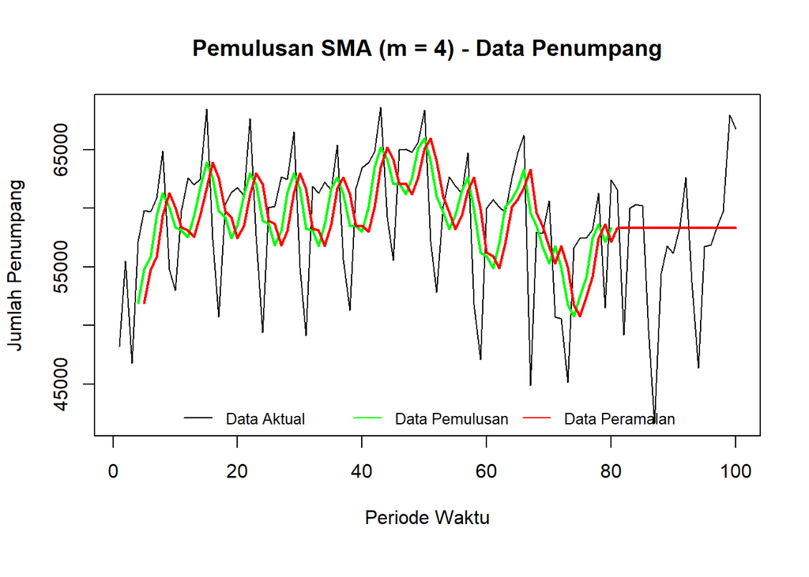

```r
par(mar = c(6, 4, 4, 2) + 0.1)
ts.plot(penumpang.ts, xlab = "Periode Waktu", ylab = "Jumlah Penumpang",
        main = "Pemulusan SMA (m = 4) - Data Penumpang")
lines(data.gab[, 2], col = "green", lwd = 2)
lines(data.gab[, 3], col = "red", lwd = 2)


legend("bottom",
       legend = c("Data Aktual", "Data Pemulusan", "Data Peramalan"),
       lty = 1,
       col = c("black", "green", "red"),
       cex = 0.8,
       horiz = TRUE,
       bty = "n")
```

## Evaluasi Akurasi SMA

### Akurasi Data Latih SMA

```r
error_train.sma <- train_ma.ts - data.ramal[1:length(train_ma.ts)]
idx_valid_train <- (m + 1):length(train_ma.ts)

SSE_train.sma  <- sum(error_train.sma[idx_valid_train]^2)
MSE_train.sma  <- mean(error_train.sma[idx_valid_train]^2)
RMSE_train.sma <- sqrt(MSE_train.sma)
MAPE_train.sma <- mean(abs((error_train.sma[idx_valid_train] / train_ma.ts[idx_valid_train])) * 100)

akurasi_train.sma <- matrix(c(SSE_train.sma, MSE_train.sma, RMSE_train.sma, MAPE_train.sma), ncol = 1)
rownames(akurasi_train.sma) <- c("SSE", "MSE", "RMSE", "MAPE (%)")
colnames(akurasi_train.sma) <- paste0("SMA (m = ", m, ")")
akurasi_train.sma
```

```
##           SMA (m = 4)
## SSE      2.928279e+09
## MSE      3.852998e+07
## RMSE     6.207253e+03
## MAPE (%) 9.398704e+00
```

### Akurasi Data Uji SMA

```r
error_test.sma <- test_ma.ts - data.gab[(n_train + 1):n, 3]

SSE_test.sma  <- sum(error_test.sma^2)
MSE_test.sma  <- mean(error_test.sma^2)
RMSE_test.sma <- sqrt(MSE_test.sma)
MAPE_test.sma <- mean(abs((error_test.sma / test_ma.ts) * 100))

akurasi_test.sma <- matrix(c(SSE_test.sma, MSE_test.sma, RMSE_test.sma, MAPE_test.sma), ncol = 1)
rownames(akurasi_test.sma) <- c("SSE", "MSE", "RMSE", "MAPE (%)")
colnames(akurasi_test.sma) <- paste0("SMA (m = ", m, ")")
akurasi_test.sma
```

```
##           SMA (m = 4)
## SSE      8.341707e+08
## MSE      4.170854e+07
## RMSE     6.458215e+03
## MAPE (%) 9.018133e+00
```

Pemulusan SMA ordo $m = 4$ menghasilkan nilai MAPE pada data latih dan data uji di bawah 10%, yang mengindikasikan kemampuan peramalan yang sangat baik (highly accurate forecasting). Namun, nilai ramalan jangka panjang SMA bersifat konstan/datar (flatline).

## Double Moving Average (DMA)

Metode Double Moving Average (DMA) melakukan pemulusan dua kali berturut-turut untuk mengakomodasi adanya kecenderungan pola tren linier.
$$S_{1,t} = \frac{1}{m}
\sum_{i=t-m+1}^{t} X_i, \quad S_{2,t} = \frac{1}{m} \sum_{i=t-m+1}^{t}
S_{1,i}$$
$$A_t = 2S_{1,t} - S_{2,t},
\quad B_t = \frac{2}{m-1}(S_{1,t} - S_{2,t})$$

```r
# Pemulusan tahap 2
dma <- SMA(data.sma, n = m)
At  <- 2 * data.sma - dma
Bt  <- (2 / (m - 1)) * (data.sma - dma)
data.dma    <- At + Bt
data.ramal2 <- c(NA, data.dma)

# Peramalan sepanjang data uji (n_test periode)
f_dma <- numeric(n_test)
for (i in 1:n_test) {
  f_dma[i] <- At[length(At)] + Bt[length(Bt)] * i
}

data.gab2 <- cbind(
  aktual     = c(penumpang.ts),
  pemulusan1 = c(data.sma, rep(NA, n_test)),
  pemulusan2 = c(dma, rep(NA, n_test)),
  At         = c(At, rep(NA, n_test)),
  Bt         = c(Bt, rep(NA, n_test)),
  ramalan    = c(data.ramal2, f_dma[-1])
)

head(data.gab2, 12)
```

```
##       aktual pemulusan1 pemulusan2       At        Bt  ramalan
##  [1,]  48208         NA         NA       NA        NA       NA
##  [2,]  55488         NA         NA       NA        NA       NA
##  [3,]  46777         NA         NA       NA        NA       NA
##  [4,]  57120   51898.25         NA       NA        NA       NA
##  [5,]  59794   54794.75         NA       NA        NA       NA
##  [6,]  59681   55843.00         NA       NA        NA       NA
##  [7,]  60904   59374.75   55477.69 63271.81 2598.0417       NA
##  [8,]  64877   61314.00   57831.62 64796.38 2321.5833 65869.85
##  [9,]  54788   60062.50   59148.56 60976.44  609.2917 67117.96
## [10,]  52970   58384.75   59784.00 56985.50 -932.8333 61585.73
## [11,]  59805   58110.00   59467.81 56752.19 -905.2083 56052.67
## [12,]  62596   57539.75   58524.25 56555.25 -656.3333 55846.98
```

### Plot hasil DMA

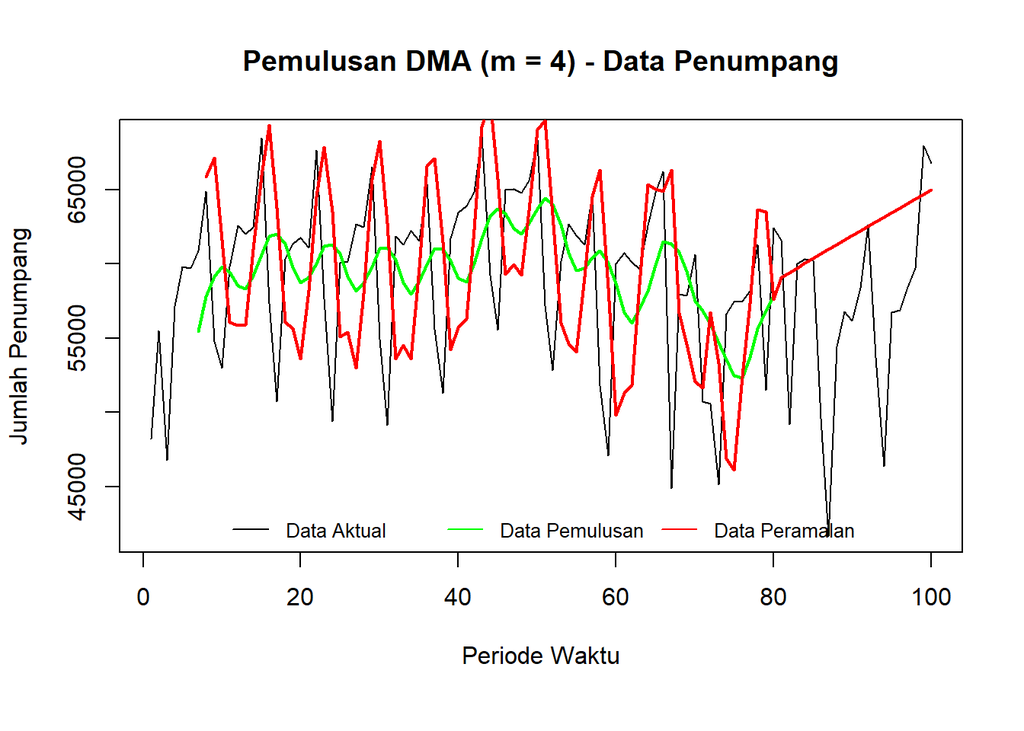

```r
par(mar = c(6, 4, 4, 2) + 0.1)
ts.plot(penumpang.ts, xlab = "Periode Waktu", ylab = "Jumlah Penumpang",
        main = "Pemulusan DMA (m = 4) - Data Penumpang")
lines(data.gab2[, 3], col = "green", lwd = 2)
lines(data.gab2[, 6], col = "red", lwd = 2)
legend("bottom",
       legend = c("Data Aktual", "Data Pemulusan", "Data Peramalan"),
       lty = 1,
       col = c("black", "green", "red"),
       cex = 0.8,
       horiz = TRUE,
       bty = "n")
```

## Evaluasi Akurasi DMA

```r
# Akurasi Data Latih DMA
error_train.dma <- train_ma.ts - data.ramal2[1:length(train_ma.ts)]
idx_valid_dma   <- (2 * m):length(train_ma.ts)

SSE_train.dma  <- sum(error_train.dma[idx_valid_dma]^2)
MSE_train.dma  <- mean(error_train.dma[idx_valid_dma]^2)
RMSE_train.dma <- sqrt(MSE_train.dma)
MAPE_train.dma <- mean(abs((error_train.dma[idx_valid_dma] / train_ma.ts[idx_valid_dma])) * 100)

akurasi_train.dma <- matrix(c(SSE_train.dma, MSE_train.dma, RMSE_train.dma, MAPE_train.dma), ncol = 1)
rownames(akurasi_train.dma) <- c("SSE", "MSE", "RMSE", "MAPE (%)")
colnames(akurasi_train.dma) <- paste0("DMA (m = ", m, ")")
akurasi_train.dma
```

```
##           DMA (m = 4)
## SSE      4.641887e+09
## MSE      6.358749e+07
## RMSE     7.974177e+03
## MAPE (%) 1.173495e+01
```

```r
# Akurasi Data Uji DMA
error_test.dma <- test_ma.ts - data.gab2[(n_train + 1):n, 6]

SSE_test.dma  <- sum(error_test.dma^2)
MSE_test.dma  <- mean(error_test.dma^2)
RMSE_test.dma <- sqrt(MSE_test.dma)
MAPE_test.dma <- mean(abs((error_test.dma / test_ma.ts) * 100))

akurasi_test.dma <- matrix(c(SSE_test.dma, MSE_test.dma, RMSE_test.dma, MAPE_test.dma), ncol = 1)
rownames(akurasi_test.dma) <- c("SSE", "MSE", "RMSE", "MAPE (%)")
colnames(akurasi_test.dma) <- paste0("DMA (m = ", m, ")")
akurasi_test.dma
```

```
##           DMA (m = 4)
## SSE      1.244521e+09
## MSE      6.222605e+07
## RMSE     7.888349e+03
## MAPE (%) 1.171664e+01
```

# SES & DES

##Single Exponential Smoothing (SES)

Metode SES memberikan bobot yang menurun secara eksponensial terhadap pengamatan historis, sangat sesuai untuk data stasioner.
$$\tilde{y}_t = \alpha y_t + (1 -
\alpha)\tilde{y}_{t-1}$$

```r
# Model SES dengan parameter coba-coba (alpha = 0.2 dan alpha = 0.7) serta Optimum
ses1   <- HoltWinters(train_ma.ts, alpha = 0.2, beta = FALSE, gamma = FALSE)
ses2   <- HoltWinters(train_ma.ts, alpha = 0.7, beta = FALSE, gamma = FALSE)
sesopt <- HoltWinters(train_ma.ts, alpha = NULL, beta = FALSE, gamma = FALSE)

# Ramalan sepanjang horizon data uji (20 periode)
ramalan1   <- forecast(ses1, h = n_test)
ramalan2   <- forecast(ses2, h = n_test)
ramalanopt <- forecast(sesopt, h = n_test)

cat("Nilai Alpha Optimum SES:", sesopt$alpha, "\n")
```

```
## Nilai Alpha Optimum SES: 0.2319537
```

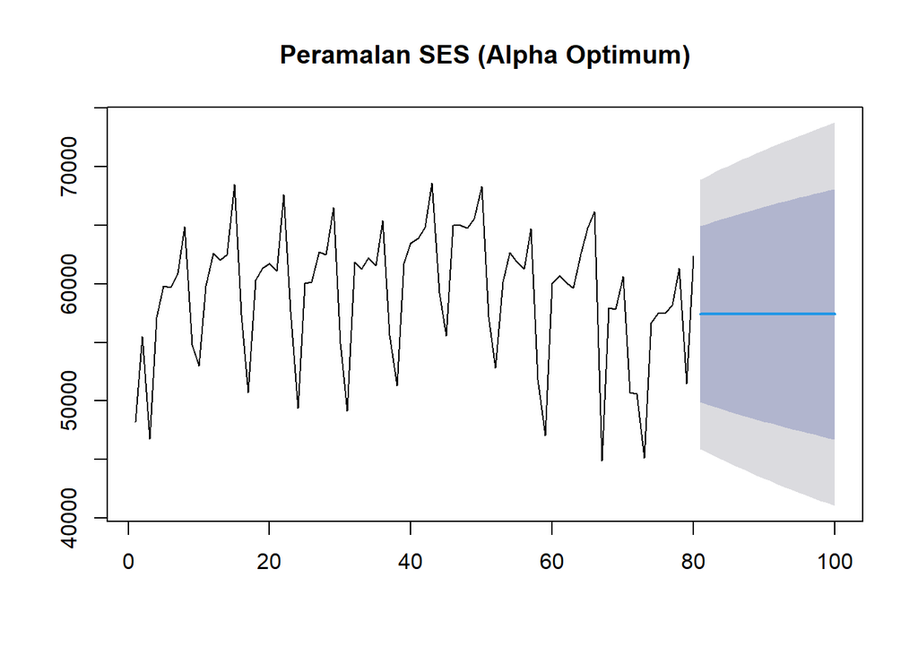

```r
# Plot hasil SES Optimum
plot(ramalanopt, main = "Peramalan SES (Alpha Optimum)")
```

## Akurasi SES Data Latih dan Uji

### Akurasi Data Latih SES

```r
SSE_train_ses1   <- ses1$SSE
MSE_train_ses1   <- SSE_train_ses1 / length(train_ma.ts)
RMSE_train_ses1  <- sqrt(MSE_train_ses1)

SSE_train_ses2   <- ses2$SSE
MSE_train_ses2   <- SSE_train_ses2 / length(train_ma.ts)
RMSE_train_ses2  <- sqrt(MSE_train_ses2)

SSE_train_sesopt  <- sesopt$SSE
MSE_train_sesopt  <- SSE_train_sesopt / length(train_ma.ts)
RMSE_train_sesopt <- sqrt(MSE_train_sesopt)
```

### Akurasi Data Uji SES

```r
acc_ses1   <- accuracy(ramalan1, as.numeric(test_ma.ts))
acc_ses2   <- accuracy(ramalan2, as.numeric(test_ma.ts))
acc_sesopt <- accuracy(ramalanopt, as.numeric(test_ma.ts))

tabel_akurasi_ses <- rbind(
  "SES (alpha = 0.2)" = acc_ses1["Test set", c("RMSE", "MAE", "MAPE")],
  "SES (alpha = 0.7)" = acc_ses2["Test set", c("RMSE", "MAE", "MAPE")],
  "SES (Optimum)"     = acc_sesopt["Test set", c("RMSE", "MAE", "MAPE")]
)
as.data.frame(tabel_akurasi_ses)
```

```
##                       RMSE      MAE     MAPE
## SES (alpha = 0.2) 6299.420 4721.250 8.845765
## SES (alpha = 0.7) 6987.636 5048.576 9.821812
## SES (Optimum)     6311.912 4721.250 8.873422
```

## Double Exponential Smoothing (DES / Metode Holt)

Metode DES mengakomodasi unsur level ($\alpha$) dan trend ($\beta$).

```r
# Model DES Holt-Winters
des.1   <- HoltWinters(train_ma.ts, alpha = 0.2, beta = 0.2, gamma = FALSE)
des.2   <- HoltWinters(train_ma.ts, alpha = 0.6, beta = 0.3, gamma = FALSE)
des.opt <- HoltWinters(train_ma.ts, alpha = NULL, beta = NULL, gamma = FALSE)

# Ramalan sepanjang horizon data uji (20 periode)
ramalandes1   <- forecast(des.1, h = n_test)
ramalandes2   <- forecast(des.2, h = n_test)
ramalandesopt <- forecast(des.opt, h = n_test)

cat("Nilai Alpha Optimum DES:", des.opt$alpha, "\n")
```

```
## Nilai Alpha Optimum DES: 0.4586385
```

```r
cat("Nilai Beta Optimum DES :", des.opt$beta, "\n")
```

```
## Nilai Beta Optimum DES : 0.2236305
```

### Plot Hasil Pemodelan DES Optimum

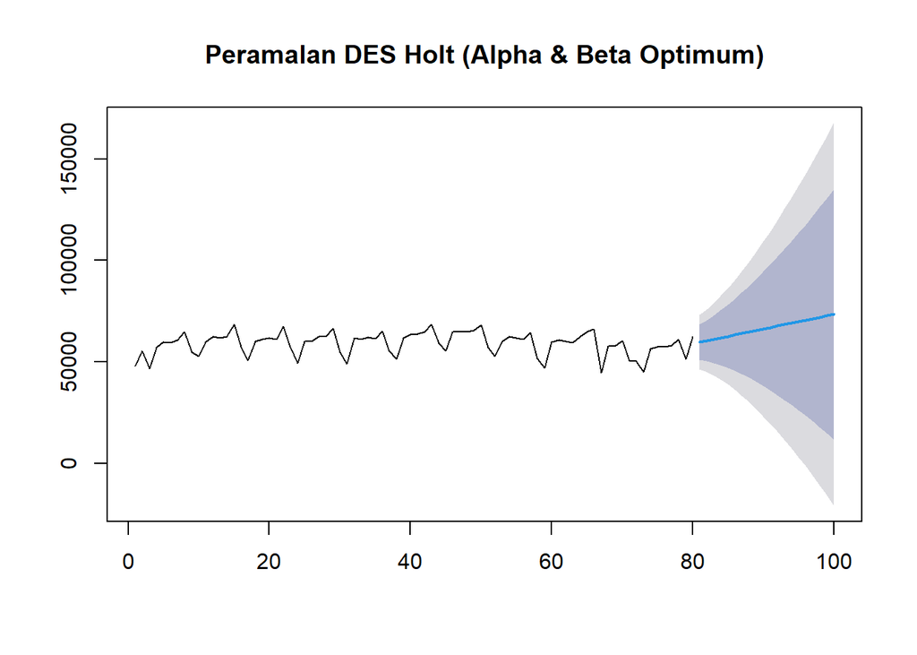

```r
plot(ramalandesopt, main = "Peramalan DES Holt (Alpha & Beta Optimum)")
```

## Akurasi DES Data Uji

```r
# Evaluasi Akurasi DES pada Data Uji
acc_des1   <- accuracy(ramalandes1, as.numeric(test_ma.ts))
acc_des2   <- accuracy(ramalandes2, as.numeric(test_ma.ts))
acc_desopt <- accuracy(ramalandesopt, as.numeric(test_ma.ts))

tabel_akurasi_des <- rbind(
  "DES (0.2 ; 0.2)" = acc_des1["Test set", c("RMSE", "MAE", "MAPE")],
  "DES (0.6 ; 0.3)" = acc_des2["Test set", c("RMSE", "MAE", "MAPE")],
  "DES (Optimum)"   = acc_desopt["Test set", c("RMSE", "MAE", "MAPE")]
)
as.data.frame(tabel_akurasi_des)
```

```
##                      RMSE       MAE      MAPE
## DES (0.2 ; 0.2)  6497.273  5188.893  9.955952
## DES (0.6 ; 0.3) 13837.576 12198.162 22.751086
## DES (Optimum)   11668.861  9976.582 18.845146
```

# Pemulusan Data Musiman: Holt-Winters

Karena data jumlah penumpang transportasi harian memiliki pola siklus mingguan (7 hari), data deret waktu dimodelkan menggunakan frekuensi musiman mingguan ($s = 7$).

```r
# Mengatur frekuensi musiman mingguan (frequency = 7)
train_season.ts <- ts(training_ma$Jumlah_Penumpang, frequency = 7)
test_season.ts  <- ts(testing_ma$Jumlah_Penumpang, frequency = 7)
```

## Holt-Winters Aditif

Model musiman aditif sesuai jika variasi musiman berfluktuasi secara relatif konstan di sekitar level tren.

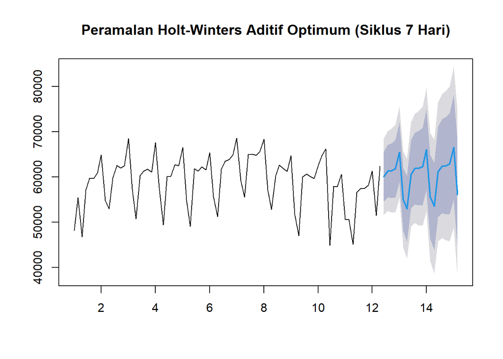

```r
# Pemulusan Holt-Winters Aditif
winter_add     <- HoltWinters(train_season.ts, alpha = 0.2, beta = 0.1, gamma = 0.1, seasonal = "additive")
winter_add_opt <- HoltWinters(train_season.ts, seasonal = "additive")

# Peramalan sepanjang data uji
ramalan_add     <- forecast(winter_add, h = n_test)
ramalan_add_opt <- forecast(winter_add_opt, h = n_test)

plot(ramalan_add_opt, main = "Peramalan Holt-Winters Aditif Optimum (Siklus 7 Hari)")
```

## Holt-Winters Multiplikatif Model multiplikatif sesuai jika amplitudo musiman bervariasi proporsional terhadap perubahan level data.

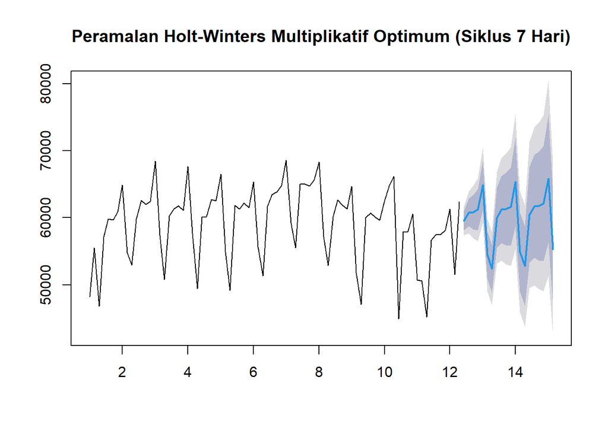

```r
# Pemulusan Holt-Winters Multiplikatif
winter_mult     <- HoltWinters(train_season.ts, alpha = 0.2, beta = 0.1, gamma = 0.3, seasonal = "multiplicative")
winter_mult_opt <- HoltWinters(train_season.ts, seasonal = "multiplicative")

# Peramalan sepanjang data uji
ramalan_mult     <- forecast(winter_mult, h = n_test)
ramalan_mult_opt <- forecast(winter_mult_opt, h = n_test)

plot(ramalan_mult_opt, main = "Peramalan Holt-Winters Multiplikatif Optimum (Siklus 7 Hari)")
```

# Perbandingan Seluruh Metode Berikut adalah tabel rekapitulasi evaluasi akurasi peramalan pada data uji (testing set) untuk menentukan metode terbaik:

```r
# Menghitung akurasi model musiman Holt-Winters
acc_hw_add  <- accuracy(ramalan_add_opt, as.numeric(test_season.ts))
acc_hw_mult <- accuracy(ramalan_mult_opt, as.numeric(test_season.ts))

# Rekapitulasi perbandingan akurasi
rekap_evaluasi <- rbind(
  "SMA (m = 4)"           = c(RMSE = RMSE_test.sma, MAE = mean(abs(error_test.sma)), MAPE = MAPE_test.sma),
  "DMA (m = 4)"           = c(RMSE = RMSE_test.dma, MAE = mean(abs(error_test.dma)), MAPE = MAPE_test.dma),
  "SES (Optimum)"         = acc_sesopt["Test set", c("RMSE", "MAE", "MAPE")],
  "DES (Optimum)"         = acc_desopt["Test set", c("RMSE", "MAE", "MAPE")],
  "Holt-Winters Aditif"   = acc_hw_add["Test set", c("RMSE", "MAE", "MAPE")],
  "Holt-Winters Multipl." = acc_hw_mult["Test set", c("RMSE", "MAE", "MAPE")]
)

# Menampilkan tabel perbandingan
as.data.frame(round(rekap_evaluasi, 3))
```

```
##                            RMSE      MAE   MAPE
## SMA (m = 4)            6458.215 4721.250  9.018
## DMA (m = 4)            7888.349 5990.017 11.717
## SES (Optimum)          6311.912 4721.250  8.873
## DES (Optimum)         11668.861 9976.582 18.845
## Holt-Winters Aditif    5962.883 5065.431  9.425
## Holt-Winters Multipl.  5611.538 4615.439  8.573
```

# KESIMPULAN